# Suspicion Index for llmpanel

## Code Status

In Progress

## Purpose

This script is used to conduct EDA and build a suspicion index to inform decision-making for any possible further exclusions from the remaining 456 eligible survey responses, prior to bringing data into the modelling workflow.

- Conduct EDA on multiple ‘variables of concern’ to establish a threshold where each variable will contribute a point towards the final suspicion index scores.
- Construct the final index, make comparisons between remaining eligible responses and manually excluded responses previously flagged.
- Decide suspicion index threshold to establish the final valid sample for analysis.

## Setup

```r
library(tidyverse)
source("https://github.com/jjcurtin/lab_support/blob/main/format_path.R?raw=true")
source("https://github.com/jjcurtin/study_llmpanel/blob/main/scripts/functions_llmpanel.R?raw=true")

path_processed <- format_path("llmpanel/data_processed")

# Read in full panel
panel <- read_csv(here::here(path_processed, "panel.csv"), show_col_types = FALSE)
```

## Variables of Concern

Each variable will be investigated separately and assigned a unique threshold for suspicion.

### IP Address

We are concerned with responses with a non-unique IP (at least 1 other survey attempt matches). While all cases of IP + demographic matches have already been flagged as duplicates and removed from the remaining eligible sample, this component will add to the suspicion index if a respondent had a matching IP address with at least 1 other survey attempt that did not match on demographics.

*Construct IP Flag*

```r
# Flag all responses with a non-unique IP
panel <- panel |>
  group_by(ip_address) |>
  mutate(
    grp_other = sum(!is.na(flag) & flag != "same_ip_dupe"),       # We are excluding cases where
    own       = as.integer(!is.na(flag) & flag != "same_ip_dupe"),# a respondent had multiple
    ip_sus    = n() > 1 & (grp_other - own) > 0                   # completed surveys from the
  ) |>                                                            # same IP with no logic fails.
  ungroup() |>
  select(-grp_other, -own)

# Separate out eligible, rejected, and a combined subset
split_panel(panel)
```

*Distributions*

```r
prop_table("ip_sus")
```

```
# A tibble: 3 × 3
  group          n_true   prop
  <chr>           <int>  <dbl>
1 Rejected n=43      18 0.419
2 Full n=499         63 0.126
3 Eligible n=456     45 0.0987
```

A higher proportion of non-unique IPs in our manually rejected responses is supporting evidence that IP address makes for a meaningful variable in the suspicion index.

### Tone Survey Straight-lining

We are concerned about responses with 0 variability in the tone preferences survey - also known as straight-lining. While respondents who straight-lined on message ratings have already been rejected, respondents who only straight-lined on the tone survey have remained eligible.

*Conduct straight-lining flag*

```r
# Flag responses with identical responses to all tone questions
panel <- panel |>
  rowwise() |>
  mutate(tone_sus = n_distinct(c_across(q1_legitimizing_1:q5_norms_1)) == 1) |>
  ungroup()

# Redefine eligible, rejected, and combined subsets
split_panel(panel)
```

*Proportions*

```r
prop_table("tone_sus")
```

```
# A tibble: 3 × 3
  group          n_true  prop
  <chr>           <int> <dbl>
1 Rejected n=43      22 0.512
2 Full n=499         97 0.194
3 Eligible n=456     75 0.164
```

Another higher proportion in the rejected subset for straight-lining! This should remain a key component in the suspicion index.

### Click Count

Click count metadata was collected by Qualtrics in addition to time spent on each survey block. Responses showing unusually high click counts may be indicative of bot scraping behavior, and may warrant suspicion as a result.

*Construct click count total*

```r
# Take the sum of all by-block click counts
panel <- panel |>
  rowwise() |>
  mutate(click_total = sum(c_across(contains("_click_count")), na.rm = TRUE)) |>
  ungroup()

# Redefine eligible, rejected, and combined subsets
split_panel(panel)
```

*Distributions*

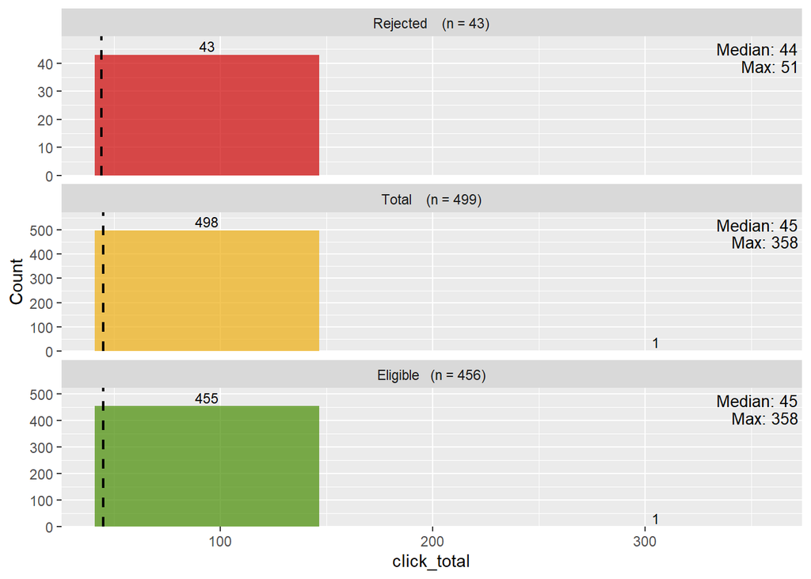

```r
compare_plot("click_total", bins = 3, display = 'max')
```

We actually have a higher median and max value in the eligible responses with a notable outlier.

```r
p_eligible |> filter(click_total == max(click_total)) |>
  summarise(clicks = click_total,
            "duration (minutes)" = q_total_duration/60,
            clickrate = q_total_duration/click_total)
```

```
# A tibble: 1 × 3
  clicks `duration (minutes)` clickrate
   <dbl>                <dbl>     <dbl>
1    358                 40.9      6.85
```

```r
min(p_full$click_total)
```

```
[1] 41
```

The outlier averaged 1 click every 6.85 seconds for the entirety of their 41-minute survey duration, which is realistically achievable by a human hand. Knowing that the survey can be completed in as little as 41 clicks, however, does indicate very excessive mouse clicking by this individual. While this could be indicative botting behavior, there are also other reasonable explanations including a broken/faulty computer mouse, happy finger, etc.

#### Clicks per second

Looking at the rate/frequency of clicks may be more informative that click count alone.

*Create click rate variable*

```r
panel <- panel |> mutate(
  click_rate = click_total/q_total_duration # Switching to clicks per 1 second
)

# Redefine eligible, rejected, and combined subsets
split_panel(panel)
```

*Distributions*

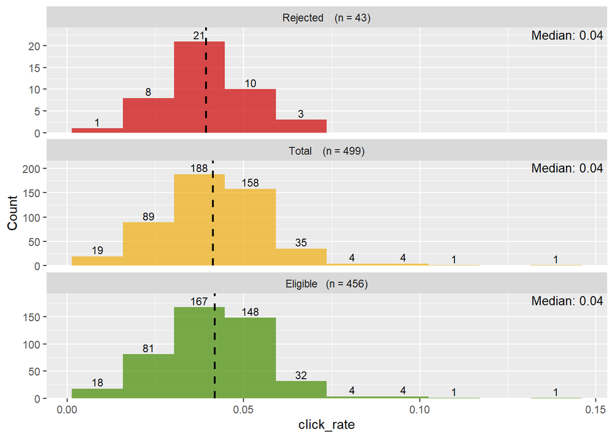

```r
compare_plot("click_rate")
```

Aside from our 1 outlier, the distribution appears roughly normal without a major discrepancy between the eligible and rejected subsets. Clicks will be excluded from the suspicion index for now.